# Question 3: Are ODE Models Useful in Glioblastoma?

Longitudinal tumour-volume modelling in the LUMIERE cohort

Author

Saidat Bello

# Study question

This report addresses Question 3 of the project brief:

> Are there any ODE models that are useful?

The analysis evaluates a simple mechanistic model of glioblastoma tumour-volume change using longitudinal LUMIERE MRI segmentations. Its usefulness is judged in two ways:

1. whether the model describes observed longitudinal tumour volumes; and
2. whether its patient-specific growth parameter is associated with the first evaluable radiographic response category.

This report follows the Question 1 cross-dataset analysis. Question 1 showed that static clinical variables did not transport adequately between Burdenko and LUMIERE; Question 3 asks whether longitudinal dynamics provide a more informative representation of response. It is kept as a separate analysis because it uses one longitudinal cohort and addresses mechanistic interpretability rather than external transportability.

Mathematical glioma models commonly represent proliferation together with spatial invasion, and patient-specific parameters can be estimated from serial MRI (Swanson *et al*., 2003). The present analysis begins with a simpler volume-only ODE because the available radiomics table provides repeated segmented volumes rather than spatial tumour-cell density.

# 1. Setup

# 2. Data and longitudinal endpoint

Each segmentation is repeated across four MRI sequences in the radiomics table. The `CT1` row is retained once for each segmentation label to avoid counting the same mask four times. Contrast-enhancing and non-enhancing volumes are added to form one total segmented tumour burden in millilitres. LUMIERE was designed to support longitudinal response-assessment research and includes automated segmentations and radiomic features alongside expert RANO ratings (Suter *et al*., 2022).

The suffixes in time points such as `week-000-1` distinguish scans acquired within the same nominal week. Small offsets preserve their ordering without pretending that their exact acquisition interval is known.

Availability of longitudinal tumour-volume measurements

| patients | median_observations | minimum_observations | maximum_observations | patients_with_three_or_more |
| --- | --- | --- | --- | --- |
| 91 | 6 | 1 | 20 | 77 |

# 3. Exponential-growth ODE

The first model is:

with analytical solution:

[ V(t)=V_0e^{rt}. ]

Here, (V(t)) is segmented tumour volume, (V_0) is patient-specific initial volume and (r) is the net weekly growth rate. Positive (r) indicates net growth and negative (r) indicates net shrinkage. This is a deliberately simple model: treatment, surgery and biological carrying capacity are not represented explicitly.

An exponential form is a reasonable baseline because near-exponential growth has been observed in some untreated glioblastomas. However, other longitudinal studies have found Gompertzian or linear-radial models to fit at least as well or better, so adequacy must be tested rather than assumed (Stensjøen *et al*., 2015).

## 3.1 Patient-level parameter estimation

Patients require at least three distinct measurements. A small offset of 0.1 ml allows zero-volume segmentations to be represented on the logarithmic scale.

Summary of patient-specific ODE fits

| fitted_patients | median_growth_rate_week | growth_rate_iqr | median_model_r_squared | median_rmse_log_volume |
| --- | --- | --- | --- | --- |
| 77 | 0.003 | 0.035 | 0.266 | 0.582 |

## 3.2 Visual assessment

The figure displays patients spanning the distribution of model fit quality.

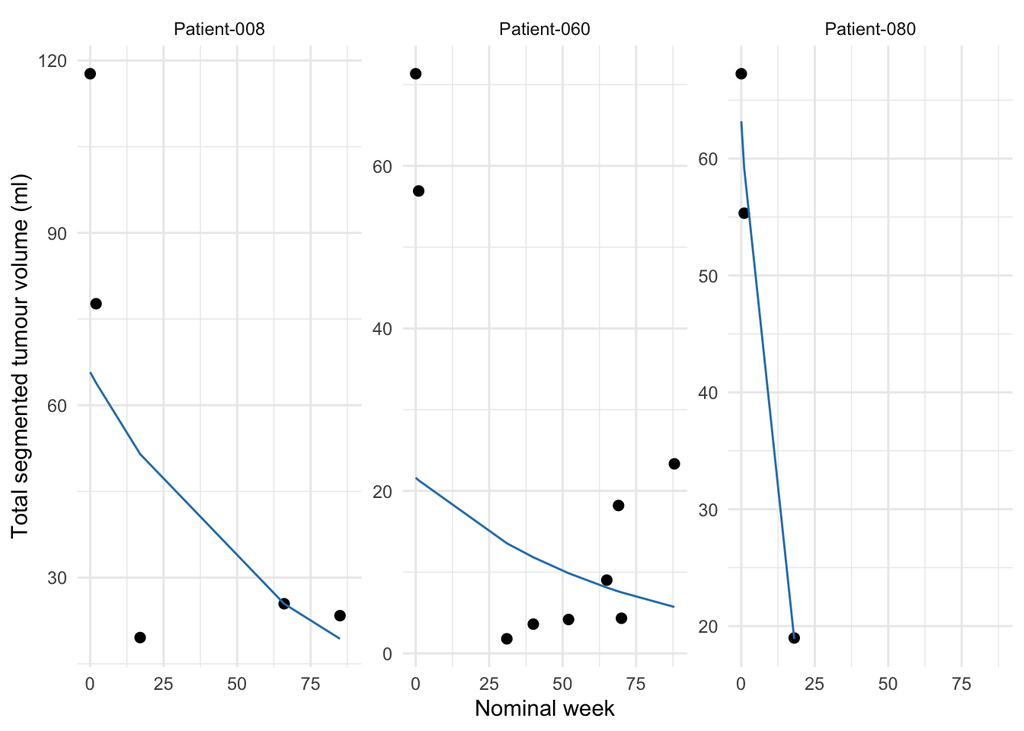

Observed tumour volumes and exponential ODE fits for illustrative patients.

# 4. Is the ODE parameter clinically useful?

The first evaluable expert RANO rating is converted to progression (`PD`) or non-progression (`SD`, `PR`, or `CR`). This matches the endpoint used in the Question 1 report.

ODE cohort by first evaluable RANO outcome

| outcome | patients |
| --- | --- |
| non_progression | 54 |
| progression | 23 |

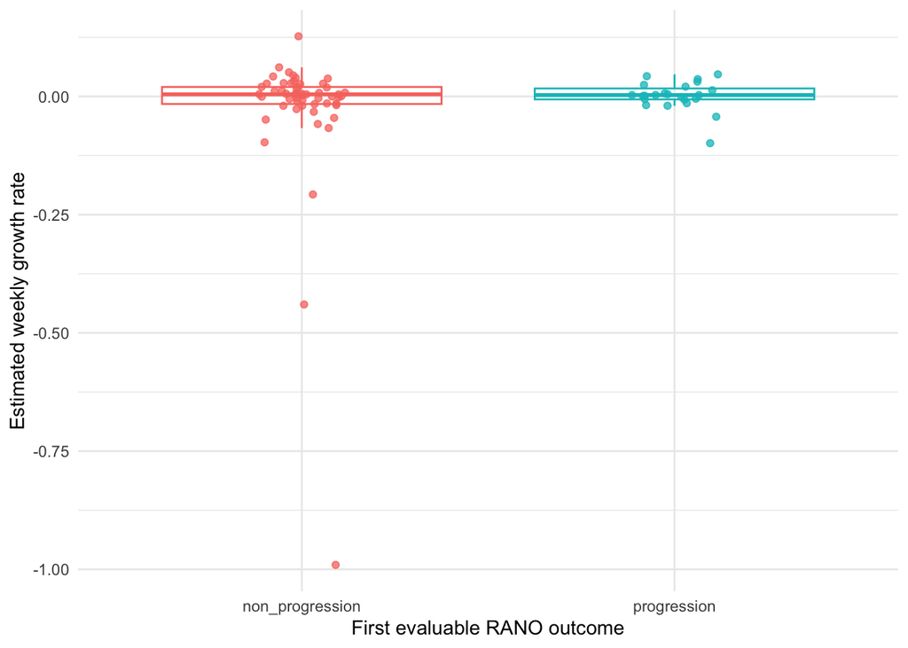

Patient-specific ODE growth rates by first evaluable RANO outcome.

Association between ODE growth rate and radiographic progression

| evaluable_patients | auc | lower_95_ci | upper_95_ci | wilcoxon_p_value |
| --- | --- | --- | --- | --- |
| 77 | 0.494 | 0.357 | 0.63 | 0.933 |

# 5. Answer to Question 3

The exponential ODE provides a compact summary of each patient’s longitudinal tumour trajectory: it converts multiple scans into a weekly net growth rate and, when positive, a tumour doubling time. However, usefulness requires more than an interpretable parameter; the model must also fit the trajectories adequately or show a clinically relevant association.

Its clinical usefulness is assessed rather than assumed. The median patient-level model (R^2) was 0.266. The growth-rate parameter distinguished first-evaluable RANO progression from non-progression with an ROC AUC of 0.494 (95% CI 0.357–0.630).

In this dataset, the median (R^2) of 0.266 indicates that a constant exponential growth rate explains only a modest proportion of within-patient variation. The AUC of 0.494 is approximately chance, its confidence interval includes 0.5, and the group-comparison (p)-value is 0.933. The answer is therefore that this simple exponential ODE has **limited descriptive value and is not useful as a clinical response predictor in its current form**.

This negative result identifies why a more realistic model is needed. A treatment-aware piecewise ODE could allow different rates before and after treatment, while a logistic or treatment-effect model could represent growth saturation and therapy-induced reduction. Those extensions require reliable scan dates and treatment timing to avoid adding unidentifiable parameters.

# 6. Limitations

1. Time is represented by nominal study week; within-week suffixes have only an ordering offset.
2. Automated segmentations may contain measurement error.
3. Enhancing plus non-enhancing volume is a pragmatic tumour-burden definition, not a full RANO assessment.
4. The model treats treatment effects as part of the net growth rate rather than estimating them separately.
5. The association with response is exploratory and is evaluated in the same cohort used to estimate the ODE parameters.

# References

Stensjøen, A.L., Solheim, O., Kvistad, K.A., Håberg, A.K., Salvesen, Ø. and Berntsen, E.M. (2015) ‘Growth dynamics of untreated glioblastomas in vivo’, *Neuro-Oncology*, 17(10), pp. 1402–1411. doi: 10.1093/neuonc/nov029.

Suter, Y., Knecht, U., Valenzuela, W., Notter, M., Hewer, E., Schucht, P., Wiest, R. and Reyes, M. (2022) ‘The LUMIERE dataset: Longitudinal glioblastoma MRI with expert RANO evaluation’, *Scientific Data*, 9, 768. doi: 10.1038/s41597-022-01881-7.

Swanson, K.R., Bridge, C., Murray, J.D. and Alvord, E.C. Jr (2003) ‘Virtual and real brain tumors: Using mathematical modeling to quantify glioma growth and invasion’, *Journal of the Neurological Sciences*, 216(1), pp. 1–10. doi: 10.1016/j.jns.2003.06.001.